# Student Representative Council

Food Attendance Experiment

Milca Arellano, Bryce Beckstead, Chaeyeon Kim & Peeraya Chamnankit

```r
src <- read_csv("C:/Users/Milca/Desktop/Statistics-Notebook-master/Data/src.csv")
src2 <- read_csv("C:/Users/Milca/Desktop/Statistics-Notebook-master/Data/src2.csv")
```

## MATH326

### Introduction

The Student Representative Council (SRC) expressed interest in an experiment to figure out if food affects the attendance of their SRC members. This gives us the ultimate question if **food truly drives people to attend meetings or not?** Knowing the answer could bring insight into human motivations and priorities. This experiment, in particular, will help SRC decide how to spend their food budget in future semesters. If the experiment shows that food does not affect attendance, they can use their budget into other activities. An article titled “Number needed to eat: pizza and resident conference attendance”[^1] talks about a study that wanted to determine if providing food at resident conferences improved attendance and arrival times. This experiment was a retrospective study of pediatric resident conference attendance over 11 months. It was found that providing complimentary food did produce a statistically significant increase in conference attendance and on-time arrivals. This study helped us design this food attendance experiment.

- *Response*: Number of attendees of each group & number of times each student attends.
  - Response should be quantitative. Total attendance is ultimately what interests the SRC.
- *Conditions*: Factor 1: Different types of emails, one mentioning that food will be provided and another making no mention of food.

Factor 2: Food, Food and No Food.

Blocking factor when analyzing the group as a whole.

- *Material*: The weekly Student Representative Council meetings, using week as a blocking factor.

The response variable is valid because the number of attendees, by group and student, is relevant to what we are looking for in the experiment, and the client’s needs and interests. This variable is also reliable because counting attendees is easily repeatable. This sample of students is uniform by how they are all members of the Student Representative Council, and they are representative of the on-campus students, with the various majors and grade-levels they represent.

### Methods

These are the steps of the experiment’s process:

1. Get a full list of members of the Student Representative Council.
2. Randomly place each member in the two separate groups with a random number generator. This randomization is essential in order to prevent any bias or variance that sorting alphabetically or in the received order could introduce.
   - **Group A** will receive the weekly meeting reminder email with a sentence that says, “Food will be provided” on weeks that food is provided. The email will make no mention of what food is provided.
   - **Group B** will receive the same email, only without the sentence saying that food will be provided. No food is mentioned at all in this email.
   - Emails are sent from the leadership of the Student Representative Council.
3. With the leaders of the Student Representative Council, randomize what weeks will have food provided and what weeks will not. Implementing this second factor is important because if food were to be provided every single week, students in Group B would inevitably learn that food will be there every week, and would confound the email variable of interest.
   - This step will also help the leadership prepare accordingly what emails to send and when to prepare food.
4. Every week, have people sign-in, to track the attendance of each group. For this experiment, the sign-in method was tablets the council leadership provided, and each student submitted their full name and email electronically.
5. Take the sign-in data and sort each attendee into the two groups they were previously randomly sorted. Count the total of how many attendees were present for each group.
6. Repeat the process for every planned week.
7. It is imperative that though the leadership of the Student Representative Council knows about the experiment, the members should be blinded entirely about these emails in order to prevent bias and variance in the results.
8. After compiling the data, use the results for appropriate analysis and decisions.

For this experiment, the data collection took place as so:

- The data collection took place every Wednesday from October 23 to November 13, totaling 4 weeks of data.
- The place the data was collected at the weekly Student Representative Council meetings.
- The data collected is the number of attendees of each email group. These figures include only SRC members and not the leadership because the leaders were aware of the experiment.
- Each group member took a turn every week to ensure the attendance data was collected at the meeting.
- The attendance data was collected electronically using Qualtrics.

### Analysis by Group

#### **Mathematical Model CB[2,1]**

$$Y_{ijk} = \mu + \alpha_i + \beta_{j} + + \gamma_k + (\alpha\beta)_{ij} + \epsilon_{ijk}$$

- $\mu$ is the grand mean
- $\alpha_i$ is the `food` factor with levels: $\space A=\text{Food (TRUE)}$ and $B=\text{No Food (FALSE)}$
- $\beta_j$ is the `email` factor with levels: $\space L=\text{Email with Food Notice (TRUE)}$ and $M=\text{Email with No Food Notice (FALSE)}$
- $\gamma_k$ is the blocking factor, week (1-4).
- $(\alpha\beta)_{ij}$ is the interaction between the two factors.
- $\epsilon_{ijk} \sim N(0,\sigma^2)$ is the error term

The hypotheses are as follows:

- **Email:** $\space H_0: \mu_{\text{food email}} = \mu_{\text{non-food email}}$  
  $H_a:\text{at least one} \space \mu \space \text{is different}$
- **Food:** $\space H_0: \mu_{\text{food week}} = \mu_{\text{non-food week}}$  
  $H_a:\text{at least one} \space \mu \space \text{is different}$
- **Significance level:** $\alpha = 0.1$, to accomodate our small sample size

#### **Data Summary**

The following table summarizes the data collected. The overall mean is 12, the minimum attendance number is 9, and the maximum attendance number is 18.

```r
src$food <- as.factor(src$food)
src$email <- as.factor(src$email)
src$week <- as.factor(src$week)
srcmod <- aov(attendance~food*email+week, data = src, contrasts = list(food = contr.sum, email = contr.sum, week=contr.sum))
pander(summary(src$attendance))
```

| Min. | 1st Qu. | Median | Mean | 3rd Qu. | Max. |
| --- | --- | --- | --- | --- | --- |
| 9 | 9.75 | 11 | 12 | 13.5 | 18 |

The following table gives more detail about every factor, with its levels. According to the table, food not provided has the highest mean meeting attendance (14) out of the two levels, the emails with food notice (when food was provided) have the highest mean meeting attendance (12.25) out of the two levels, and the first block (week 1) has the highest mean meeting attendance (16.5) out of all the blocks.

```r
pander(favstats(attendance~food, data=src))
```

| food | min | Q1 | median | Q3 | max | mean | sd | n | missing |
| --- | --- | --- | --- | --- | --- | --- | --- | --- | --- |
| FALSE | 10 | 12.25 | 14 | 15.75 | 18 | 14 | 3.367 | 4 | 0 |
| TRUE | 9 | 9 | 9.5 | 10.5 | 12 | 10 | 1.414 | 4 | 0 |

```r
pander(favstats(attendance~email, data=src))
```

| email | min | Q1 | median | Q3 | max | mean | sd | n | missing |
| --- | --- | --- | --- | --- | --- | --- | --- | --- | --- |
| FALSE | 9 | 9.75 | 10 | 12 | 18 | 11.75 | 4.193 | 4 | 0 |
| TRUE | 9 | 11.25 | 12.5 | 13.5 | 15 | 12.25 | 2.5 | 4 | 0 |

```r
pander(favstats(attendance~week, data=src))
```

| week | min | Q1 | median | Q3 | max | mean | sd | n | missing |
| --- | --- | --- | --- | --- | --- | --- | --- | --- | --- |
| 1 | 15 | 15.75 | 16.5 | 17.25 | 18 | 16.5 | 2.121 | 2 | 0 |
| 2 | 9 | 9 | 9 | 9 | 9 | 9 | 0 | 2 | 0 |
| 3 | 10 | 10.5 | 11 | 11.5 | 12 | 11 | 1.414 | 2 | 0 |
| 4 | 10 | 10.75 | 11.5 | 12.25 | 13 | 11.5 | 2.121 | 2 | 0 |

The biggest weakness that could affect the analysis of the study is the number of meetings in the sample. Only four meetings were included. Therefore the results might not be reliable.

The following graphs show the five-number summary of the levels in both factors. It gives an estimate of what the minimum, first quartile, second quartile (median), third quartile, and the maximum are. According to the following graph, food not provided has a higher median meeting attendance than the food provided.

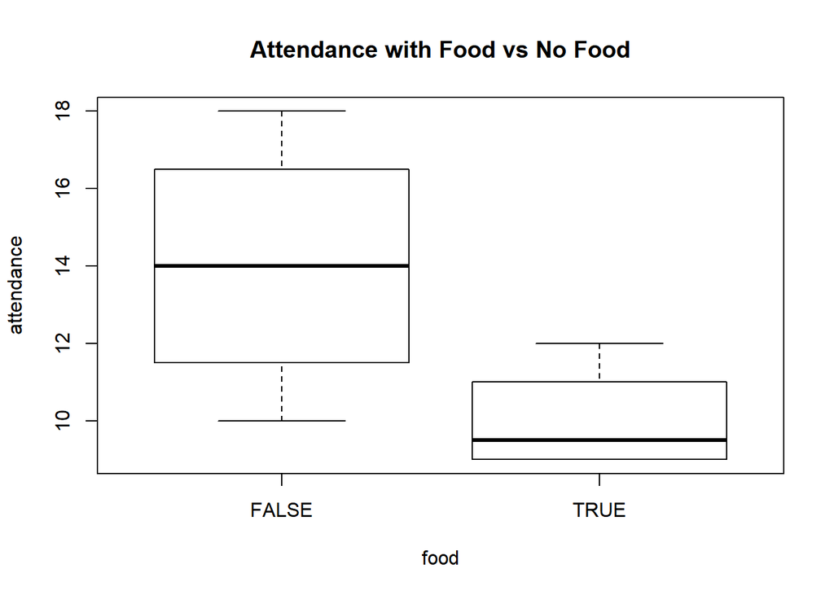

```r
boxplot(attendance~food, data=src, main = "Attendance with Food vs No Food")
```

According to the following graph, the emails with food notice (when food was provided) have a higher median meeting attendance than the emails with no food notice.

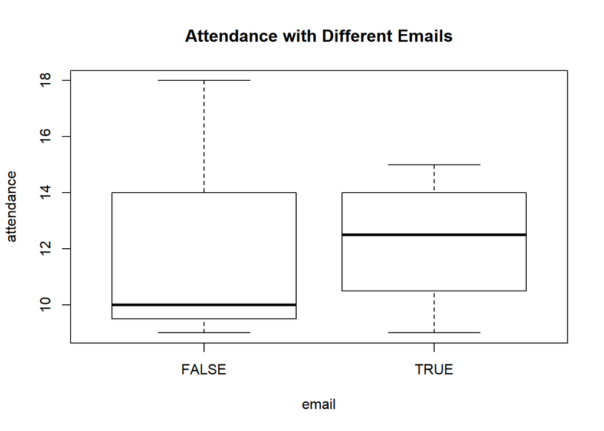

```r
boxplot(attendance~email, data=src, main = "Attendance with Different Emails")
```

According to the following graph, the first week had a higher median meeting attendance than the other weeks.

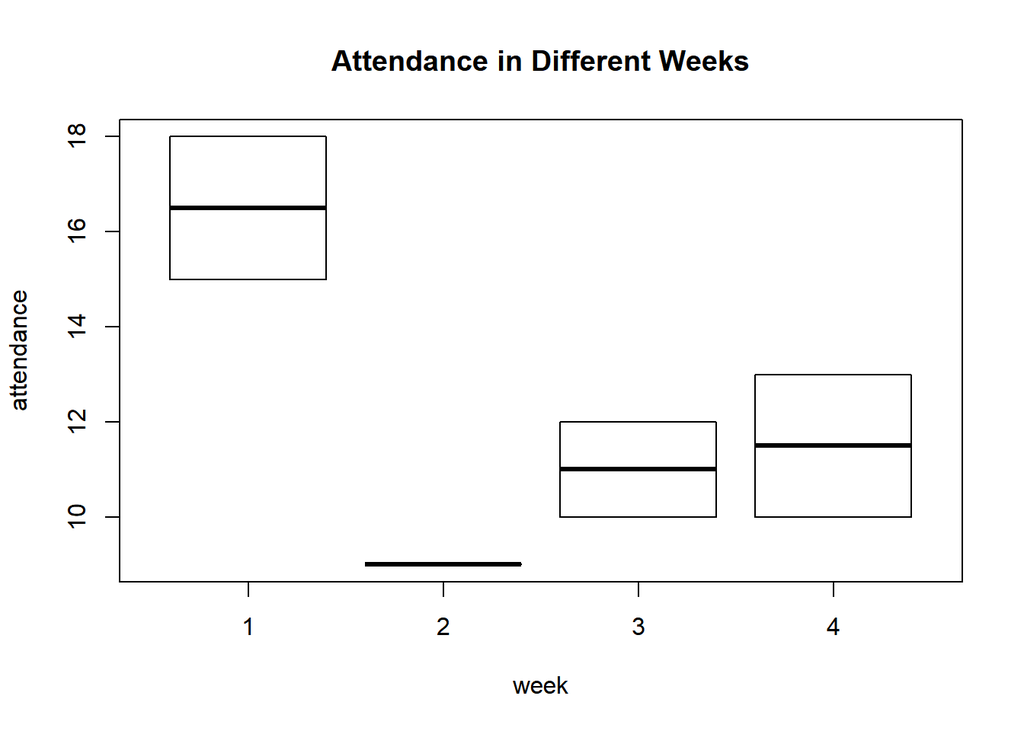

```r
boxplot(attendance~week, data=src, main = "Attendance in Different Weeks")
```

The following graph shows the interaction between the two factors (food and emails). According to the graph, there seems to be an interaction between the two factors because the lines are not parallel.

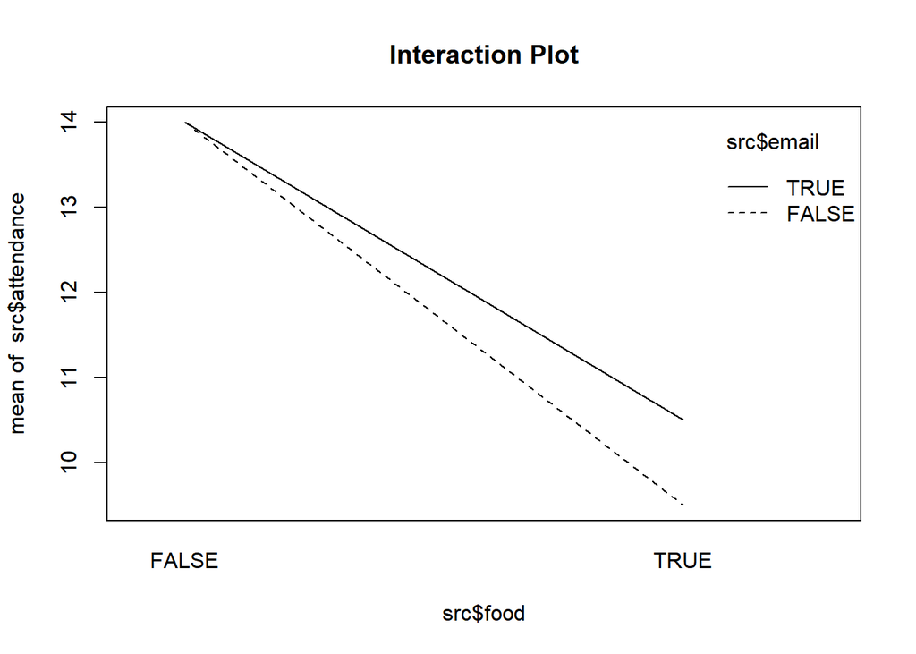

```r
interaction.plot(src$food, src$email, src$attendance, main = "Interaction Plot")
```

#### *Residuals are normally distributted*

One of the requirements is that the residuals are normally distributed. The following Q-Q plot is used to check the normality of the residuals. The requirement is met because all the residuals are inside of the dashed lines.

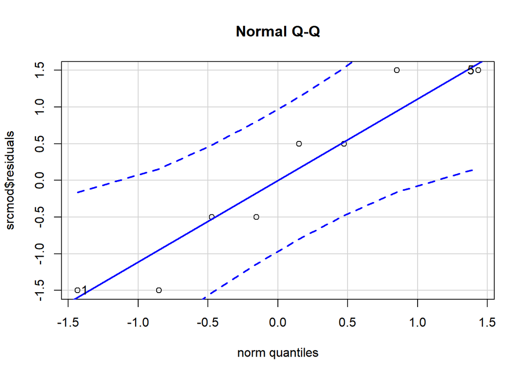

```
## [1] 5 1
```

```r
car::qqPlot(srcmod$residuals, main = "Normal Q-Q")
```

#### *Constant variance of the errors*

Another requirement is that the residuals have constant variances. This is checked by looking at the following graph and table. The variances in the Residuals vs Fitted plot do not seem to be constant because they appear to follow a megaphone shape, but they can also be checked by looking at the standard deviations in the following tables. The variances are constant if the largest standard deviation divided by the smallest standard deviation is less than or equal to 3, this requirement is met because 3.367/1.414 is equal to 2.381, and 4.193/2.5 is 1.677.

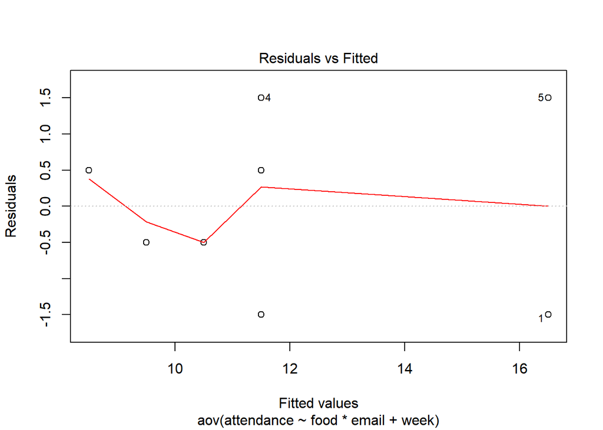

```r
plot(srcmod, which = 1)
```

```r
pander(favstats(attendance~food, data=src))
```

| food | min | Q1 | median | Q3 | max | mean | sd | n | missing |
| --- | --- | --- | --- | --- | --- | --- | --- | --- | --- |
| FALSE | 10 | 12.25 | 14 | 15.75 | 18 | 14 | 3.367 | 4 | 0 |
| TRUE | 9 | 9 | 9.5 | 10.5 | 12 | 10 | 1.414 | 4 | 0 |

```r
pander(favstats(attendance~email, data=src))
```

| email | min | Q1 | median | Q3 | max | mean | sd | n | missing |
| --- | --- | --- | --- | --- | --- | --- | --- | --- | --- |
| FALSE | 9 | 9.75 | 10 | 12 | 18 | 11.75 | 4.193 | 4 | 0 |
| TRUE | 9 | 11.25 | 12.5 | 13.5 | 15 | 12.25 | 2.5 | 4 | 0 |

```r
pander(favstats(attendance~week, data=src))
```

| week | min | Q1 | median | Q3 | max | mean | sd | n | missing |
| --- | --- | --- | --- | --- | --- | --- | --- | --- | --- |
| 1 | 15 | 15.75 | 16.5 | 17.25 | 18 | 16.5 | 2.121 | 2 | 0 |
| 2 | 9 | 9 | 9 | 9 | 9 | 9 | 0 | 2 | 0 |
| 3 | 10 | 10.5 | 11 | 11.5 | 12 | 11 | 1.414 | 2 | 0 |
| 4 | 10 | 10.75 | 11.5 | 12.25 | 13 | 11.5 | 2.121 | 2 | 0 |

#### **Analysis of Variance**

```r
pander(anova(srcmod))
```

Analysis of Variance Table

|  | Df | Sum Sq | Mean Sq | F value | Pr(>F) |
| --- | --- | --- | --- | --- | --- |
| **food** | 1 | 32 | 32 | 6.4 | 0.1271 |
| **email** | 1 | 0.5 | 0.5 | 0.1 | 0.7818 |
| **week** | 2 | 29 | 14.5 | 2.9 | 0.2564 |
| **food:email** | 1 | 0.5 | 0.5 | 0.1 | 0.7818 |
| **Residuals** | 2 | 10 | 5 | NA | NA |

### t-Tests by Individual

#### **Email**

The null and alternative hypotheses are shown below.

$$H_0: \mu_\text{email} - \mu_\text{non-email} = 0$$

$$H_a: \mu_\text{email} - \mu_\text{non-email} \neq 0$$

$$\alpha = 0.05$$

```r
pander(t.test(attendance ~ email, data = src2, mu = 0, alternative = "two.sided", conf.level = 0.95))
```

Welch Two Sample t-test: `attendance` by `email` (continued below)

| Test statistic | df | P value | Alternative hypothesis |
| --- | --- | --- | --- |
| 0.5132 | 89.84 | 0.6091 | two.sided |

| mean in group FALSE | mean in group TRUE |
| --- | --- |
| 1.109 | 1.022 |

With a p-value of `0.6091` being greater than the `0.05` significance level, we fail to reject our null hypothesis. This tells us that with the type of email, whether it mentions food is provided or not, has not effect on attendance.

#### **Food**

The null and alternative hypotheses are shown below.

$$H_0: \mu_\text{food week} - \mu_\text{non-food week} = 0$$

$$H_a: \mu_\text{food week} - \mu_\text{non-food week} \neq 0$$

$$\alpha = 0.05$$

```r
pander(t.test(attendance ~ food, data = src2, mu = 0, alternative = "two.sided", conf.level = 0.95))
```

Welch Two Sample t-test: `attendance` by `food` (continued below)

| Test statistic | df | P value | Alternative hypothesis | mean in group FALSE |
| --- | --- | --- | --- | --- |
| 2.099 | 80 | 0.03894 * | two.sided | 1.239 |

| mean in group TRUE |
| --- |
| 0.8913 |

### Conclusion

The analysis shows no difference between each level of the treatments. The assumptions were met for the analysis of the whole group. We performed an incomplete block experiment and we failed to reject the null hypothesis for food, email, and the interaction between food and email. We have insufficient evidence to say that at least one of the means for the food factor is different. We have insufficient evidence to say that at least one of the means for the email factor is different. We also have insufficient evidence to say that there is any interaction between food and email.

There are some weak points in our studies. Our sample size could have been much larger, so our data to suggest an interaction between food and the number of people attending meetings was limited. We have found significant results for the t-Test comparing food vs no food. This is because the sample size was large enough for us to be able to detect differences, as compared to the incomplete block design analyzing the group as a whole. For future research, we would suggest that they take the factors of time of day and how the meeting was organized into account.

### References

**The following are additional references that guided us towards this project’s question and motivations:**

2. Pope, L. & Harvey, J. (2015). The impact of incentives on intrinsic and extrinsic motives for fitness-center attendance in college first-year students. American Journal of Health Promotion, 29(3), 192-199. doi: 10.4278/ajhp.140408-QUAN-135
3. Silva, M. R., Kleinert, W. L., Sheppard, A. V., Cantrell, K. A., Freeman-Coppadge, D. J., Tsoy, E., … Pearrow, M. (2017). The Relationship between Food Security, Housing Stability, and School Performance among College Students in an Urban University. Journal of College Student Retention: Research, Theory & Practice, 19(3), 284–299. Retrieved from http://search.ebscohost.com.byui.idm.oclc.org/login.aspx?direct=true&db=eric&AN=EJ1156658&site=ehost-live
4. Segovis, Colin M. “If You Feed Them, They Will Come: A Prospective Study of the Effects of Complimentary Food on Attendance and Physician Attitudes at Medical Grand Rounds at an Academic Medical Center.” BMC Medical Education, 12 July 2007, https://bmcmededuc.biomedcentral.com/articles/10.1186/1472-6920-7-22#Sec8
5. Reasons for Missing Classes in College; the Role of Personality Traits https://www.sciencedirect.com/science/article/pii/S1877042815050648?via%3Dihub Rijavec M, Miljkovic D. Reasons for Missing Classes in College; the Role of Personality Traits. Procedia - Social and Behavioral Sciences. 2015;205:480-484. doi:10.1016/j.sbspro.2015.09.046.
6. Effects of a free school breakfast programme on school attendance, achievement, psychosocial function, and nutrition: a stepped wedge cluster randomised trial. Ni Mhurchu, C., Turley, M., Gorton, D., Jiang, Y., Michie, J., Maddison, R., & Hattie, J. (2010). Effects of a free school breakfast programme on school attendance, achievement, psychosocial function, and nutrition: a stepped wedge cluster randomised trial. BMC Public Health, 10, 738. https://doi.org/10.1186/1471-2458-10-738
[^1]: Cosimini, M.J., Mackintosh, L., & Chang, T.P. (2016). Number needed to eat: pizza and resident conference attendance. Medical Education, 50(12), 1204-1207. doi: 10.1111/medu.13080